# Cow Creek

Sadie Gill, Mark Tompkins

July 1, 2019

## Floodplain Modeling Details

### Fall Run

No site-specific hydraulic modeling was available for this watershed. A flow to floodplain area relationship was generated for this watershed by scaling the flow to floodplain area relationship for Deer Creek based on hydrologic and geomorphic analyses. Flows and corresponding floodplain areas per unit length were calculated for this watershed as 216% of Deer Creek values based on the ratio of mean flow from December to June between this watershed and Deer Creek. Of the entire mapped 64.17 mile rearing extent in this watershed, 8.59 miles were classified as low gradient and 55.58 miles were classified as high gradient based on a geomorphic analysis. A scaling factor of 0.1 was applied to the area per unit length for the high gradient extent. No scaling factor was applied to the low gradient extent.

### Steelhead

No site-specific hydraulic modeling was available for this watershed. A flow to floodplain area relationship was generated for this watershed by scaling the flow to floodplain area relationship for Deer Creek based on hydrologic and geomorphic analyses. Flows and corresponding floodplain areas per unit length were calculated for this watershed as 216% of Deer Creek values based on the ratio of mean flow from December to June between this watershed and Deer Creek. Of the entire mapped 94.19 mile rearing extent in this watershed, 8.59 miles were classified as low gradient and 85.60 miles were classified as high gradient based on a geomorphic analysis. A scaling factor of 0.1 was applied to the area per unit length for the high gradient extent. No scaling factor was applied to the low gradient extent.

## Floodplain Data

| flow_cfs | FR_floodplain_acres | ST_floodplain_acres | watershed |
| --- | --- | --- | --- |
| 1660.290 | 0.000000 | 0.000000 | Cow Creek |
| 1875.912 | 6.383165 | 7.737547 | Cow Creek |
| 2091.534 | 18.745913 | 22.723428 | Cow Creek |
| 2307.156 | 29.115228 | 35.292909 | Cow Creek |
| 2522.778 | 40.267350 | 48.811293 | Cow Creek |

*…with 17 more rows*

## Floodplain Plot

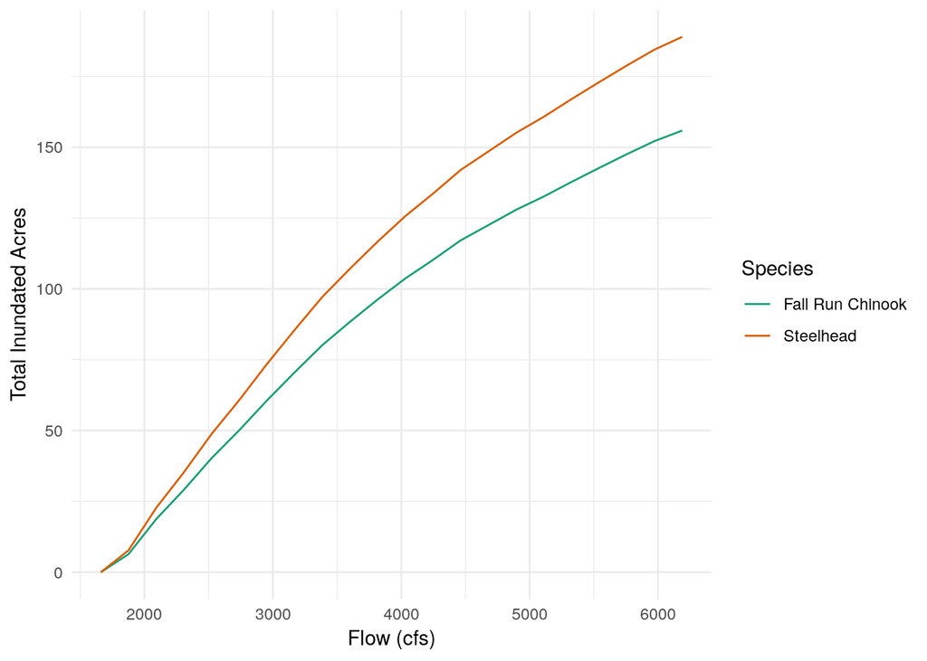